# ex2p268Corrige

## Données issues de l'exercice 2 p. 268

Un organisme de santé publique a organisé une pesée des sacs pour chacun des élèves d'un lycée.  
Les masses sont arrondiées au kg près.

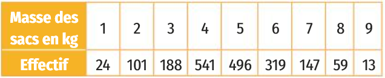

1. Construire deux listes en python contenant les données ci-dessus.

```python
masses = [1, 2, 3, 4, 5, 6, 7, 8, 9]
effectifs = [24, 101, 188, 541, 496, 319, 147, 59, 13]
```

1. Que devons nous écrire pour faire apparaitre l'effectif de la valeur 5 ?

```python
effectifs[4]
```

```
496
```

1. En vous aidant de la partie I-b) du cours, créer un programme permettant de calculer le nombre total de sacs (et donc d'élèves de ce lycée).

```python
effTotal = 0
for elt in effectifs:
    effTotal = effTotal + elt
print(effTotal)
```

```
1888
```

1. On s'intéresse alors aux effectifs cumulés croissants (E.C.C.).  
   Construire une liste contenant ces effectifs cumulés croissants (là aussi il faut juste adapter ce qui a été fait en cours).

```python
ECC = [effectifs[0]]
for i in range(1, len(effectifs)):
    ECC.append(effectifs[i]+ECC[i-1])
print(ECC)
```

```
[24, 125, 313, 854, 1350, 1669, 1816, 1875, 1888]
```

1. Construire, comme ce qui a été fait en cours, la liste des fréquences.

```python
frequences = []
for elt in effectifs:
    frequences.append(elt/effTotal)
print(frequences)
```

```
[0.012711864406779662, 0.05349576271186441, 0.09957627118644068, 0.2865466101694915, 0.2627118644067797, 0.16896186440677965, 0.07786016949152542, 0.03125, 0.006885593220338983]
```

1. En vous inspirant de ce qui a été fait pour les E.C.C., créer une autre liste qui contiendra les fréquences cumulées croissantes (F.C.C.).

```python
FCC = [frequences[0]]
for i in range(1, len(frequences)):
    FCC.append(frequences[i]+FCC[i-1])
print(FCC)
```

```
[0.012711864406779662, 0.06620762711864407, 0.16578389830508475, 0.45233050847457623, 0.715042372881356, 0.8840042372881356, 0.961864406779661, 0.993114406779661, 1.0]
```

1. On souhaite maintenant répondre aux question de l'exercice, mais nous allons le faire en demandant la réponse à python.

a) Écrire la commande qui vous donnera le nombre d'élèves qui portent un sac de 4 kg ou moins.

```python
ECC[3]
```

```
854
```

b) Écrire la commande qui vous donnera le nombre d'élèves qui portent un sac d'au moins 8 kg.

```python
effTotal-ECC[6] ##J'enlève à l'effectif total le nombre d'élèves qui portent un sac de 7kg ou moins
```

```
72
```

c) Écrire la commande qui vous donnera la proportion d'élèves portant un sac de 3 kg.

```python
frequences[2]
```

```
0.09957627118644068
```

d) Écrire la commande qui vous donnera la proportion d'élèves portant un sac de 5 kg ou moins.

```python
FCC[4]
```

```
0.715042372881356
```